# Measure and compare network metrics from simulated community with empirical ones

```r
library(ggplot2)

my.theme<-theme(axis.text=element_text(size=12),
                axis.title = element_text(size = 14),
                legend.position = "top",
                legend.text=element_text(size=10),
                legend.title = element_text(size=12),
                plot.title = element_text(face="bold",size=14,margin=margin(0,0,20,0),hjust = 0.5),
                axis.title.y = element_text(margin = margin(t = 0, r = 15, b = 0, l = 0)),
                axis.title.x = element_text(margin = margin(t = 15, r = 0, b = 0, l = 0)))
```

these metrics used in: https://www.nature.com/articles/s41598-019-54443-0

1. Number of species within the foodweb (S)
2. liks density (L/S)
3. directed connectance (C = L/S2)
4. %T (Top species that have resource species but lack any consumer species)
5. % I (Intermediate species that have both resource and consumer species)
6. % B (Basal species that have consumer species but lack resources species)
7. %C (Cannibal species that eat themselves)
8. %Omn (species that eat species at different trophic levels)
9. Standard deviation of mean generality (GenSD)
10. Standard deviation of mean vulnerability (VulSD)

Reference page: https://rfrelat.github.io/BalticFoodWeb.html

```r
library(fluxweb)
library(NetIndices)
library(ggplot2)
library(reshape2)
library(data.table)
library(purrr)
library(here)
library(igraph)
library(stringr)
library(ggpubr)
source("functions/functions_metrics_networks.R")
source("functions/functions_phylo_signal.R")
```

# Compare metrics between scenarios to choose the best one

## Neutral

### Get data paths

```r
# Make a vector of all your file paths

file_paths_n <- list.files(path = here::here("data/neutral/"), pattern = ".rds", full.names = TRUE)


# Make a vector of file names
file_names_n <-  gsub(pattern = ".rds$", replacement = "", x = basename(file_paths_n))
```

### Compute network metrics

Get the adjacency matrix of each simulation and compute the network metrics

```r
# Get adjacency matrix from each simulation object stored in our folder

adj_matrix_list_n <-  get_adjancency_from_simulation.objects(file_path = file_paths_n)
```

[output not shown]

Identify each scenario

| Group.1 | S | Link_density | C | perc_tops | perc_int | perc_basals | perc_cannibals | omnivory | mean_gen | sd_gen | mean_vul | sd_vul | sc |
| --- | --- | --- | --- | --- | --- | --- | --- | --- | --- | --- | --- | --- | --- |
| 1 | 47.2 | 21.98358 | 0.4634167 | 0.0000000 | 100.00000 | 0.0000000 | 0 | 3.278715 | 21.98358 | 8.821920 | 21.98358 | 5.537212 | NA |
| 10 | 45.0 | 18.74136 | 0.4149879 | 0.0000000 | 96.44187 | 3.5581345 | 0 | 3.205233 | 19.33701 | 9.037913 | 18.74136 | 5.874790 | NA |
| 15 | 37.2 | 14.64159 | 0.3940057 | 0.0000000 | 95.62296 | 4.3770396 | 0 | 2.762615 | 15.19595 | 8.100810 | 14.64159 | 4.959654 | NA |
| 2 | 49.0 | 20.82410 | 0.4243751 | 0.0000000 | 99.59184 | 0.4081633 | 0 | 3.205150 | 20.89451 | 10.787617 | 20.82410 | 5.649233 | NA |
| 3 | 50.6 | 17.96191 | 0.3552690 | 0.0000000 | 98.41506 | 1.5849355 | 0 | 2.798868 | 18.21133 | 10.068752 | 17.96191 | 5.662255 | NA |
| 4 | 49.2 | 19.72548 | 0.4029486 | 0.0000000 | 98.03077 | 1.5692308 | 0 | 4.026834 | 20.02246 | 10.151664 | 19.77169 | 7.508846 | NA |
| 5 | 50.0 | 20.32744 | 0.4048407 | 0.4000000 | 97.58367 | 1.2081633 | 0 | 3.451825 | 20.61574 | 10.574565 | 20.51065 | 5.922832 | NA |
| 6 | 41.8 | 16.10833 | 0.3845380 | 0.9307359 | 94.73244 | 4.3368260 | 0 | 2.866390 | 16.72445 | 9.792540 | 16.24452 | 5.642658 | NA |
| 7 | 44.2 | 14.86931 | 0.3368915 | 0.0000000 | 97.29149 | 1.8196248 | 0 | 2.721922 | 15.23404 | 9.360519 | 14.98838 | 4.914233 | NA |
| 8 | 45.2 | 17.78972 | 0.3935154 | 0.0000000 | 99.11067 | 0.4347826 | 0 | 3.081906 | 17.98511 | 8.606604 | 17.89226 | 5.088979 | NA |

[output cut: 1 more lines]

Calculate means of simulations per scenario

| scenario | S | Link_density | C | perc_tops | perc_int | perc_basals | perc_cannibals | omnivory | mean_gen | sd_gen | mean_vul | sd_vul | sc |
| --- | --- | --- | --- | --- | --- | --- | --- | --- | --- | --- | --- | --- | --- |
| 1 | 47.2 | 21.98358 | 0.4634167 | 0.0000000 | 100.00000 | 0.0000000 | 0 | 3.278715 | 21.98358 | 8.821920 | 21.98358 | 5.537212 | NA |
| 10 | 45.0 | 18.74136 | 0.4149879 | 0.0000000 | 96.44187 | 3.5581345 | 0 | 3.205233 | 19.33701 | 9.037913 | 18.74136 | 5.874790 | NA |
| 15 | 37.2 | 14.64159 | 0.3940057 | 0.0000000 | 95.62296 | 4.3770396 | 0 | 2.762615 | 15.19595 | 8.100810 | 14.64159 | 4.959654 | NA |
| 2 | 49.0 | 20.82410 | 0.4243751 | 0.0000000 | 99.59184 | 0.4081633 | 0 | 3.205150 | 20.89451 | 10.787617 | 20.82410 | 5.649233 | NA |
| 3 | 50.6 | 17.96191 | 0.3552690 | 0.0000000 | 98.41506 | 1.5849355 | 0 | 2.798868 | 18.21133 | 10.068752 | 17.96191 | 5.662255 | NA |
| 4 | 49.2 | 19.72548 | 0.4029486 | 0.0000000 | 98.03077 | 1.5692308 | 0 | 4.026834 | 20.02246 | 10.151664 | 19.77169 | 7.508846 | NA |
| 5 | 50.0 | 20.32744 | 0.4048407 | 0.4000000 | 97.58367 | 1.2081633 | 0 | 3.451825 | 20.61574 | 10.574565 | 20.51065 | 5.922832 | NA |
| 6 | 41.8 | 16.10833 | 0.3845380 | 0.9307359 | 94.73244 | 4.3368260 | 0 | 2.866390 | 16.72445 | 9.792540 | 16.24452 | 5.642658 | NA |
| 7 | 44.2 | 14.86931 | 0.3368915 | 0.0000000 | 97.29149 | 1.8196248 | 0 | 2.721922 | 15.23404 | 9.360519 | 14.98838 | 4.914233 | NA |
| 8 | 45.2 | 17.78972 | 0.3935154 | 0.0000000 | 99.11067 | 0.4347826 | 0 | 3.081906 | 17.98511 | 8.606604 | 17.89226 | 5.088979 | NA |

[output cut: 1 more lines]

|  | 3 | 5 | 6 | 7 | 8 | 9 | 10 | 11 | 12 | 13 | 14 | 15 | 16 | scenario |
| --- | --- | --- | --- | --- | --- | --- | --- | --- | --- | --- | --- | --- | --- | --- |
| 1 | 183 | 80 | 1045 | 219 | 61 | 378 | 449 | 534 | 0 | 49 | 165 | 840 | 1173 | A |
| 2 | 208 | 57 | 717 | 78 | 134 | 891 | 195 | 301 | 0 | 50 | 157 | 892 | 1784 | B |
| 3 | 216 | 1 | 294 | 45 | 25 | 134 | 12 | 33 | 0 | 2 | 52 | 153 | 150 | C |
| 4 | 452 | 86 | 1411 | 149 | 141 | 590 | 375 | 554 | 0 | 72 | 412 | 1324 | 1734 | D |
| 5 | 459 | 154 | 1018 | 198 | 215 | 326 | 204 | 183 | 0 | 35 | 285 | 482 | 356 | E |
| 6 | 284 | 67 | 700 | 135 | 84 | 313 | 241 | 120 | 0 | 37 | 205 | 414 | 626 | F |
| 7 | 192 | 64 | 1884 | 175 | 54 | 467 | 710 | 973 | 0 | 133 | 379 | 1756 | 4965 | G |
| 8 | 236 | 34 | 1266 | 137 | 80 | 445 | 300 | 532 | 0 | 98 | 208 | 1147 | 2100 | H |
| 9 | 222 | 41 | 708 | 132 | 75 | 322 | 79 | 160 | 0 | 22 | 80 | 292 | 504 | I |
| 10 | 519 | 102 | 1548 | 378 | 224 | 948 | 338 | 282 | 0 | 55 | 584 | 1361 | 1672 | A0 |

[output cut: 45 more lines]

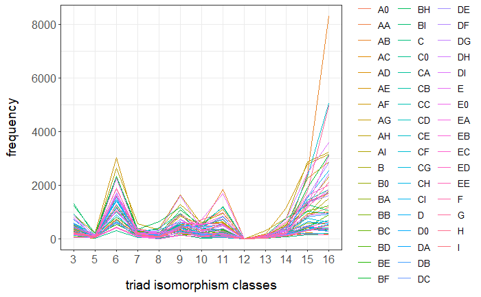

[figure not shown]

```r
motifs_n_sim
```

# Once scenarios are chosen, compare with empirical

## Metrics from empirical networks

see: https://mlurgi.github.io/networks_for_r/lesson-4.html

```r
# Make a vector of all your file paths

file_paths_emp <- list.files(path = here::here("C:/Users/alexf/Desktop/empirical_foodwebs/csv/"), pattern = ".csv", full.names = TRUE)
```

| ID | Species | Interactions | Connectance | Type.of.interactions | Type.of.data | Reference | Locality.of.Study | Latitude | Longitude |
| --- | --- | --- | --- | --- | --- | --- | --- | --- | --- |
| FW_001 | 40 | 185 | 0.237 | Food Webs | 1 | Angelini, R., Agostinho A. (2005) Food web model of the Upper Paran Ì\201a River Floodplain: description and aggregation effects. Ecological Modelling 181: 109â\200“121 | Parana, Brazil | -24.484219 | -51.814887 |
| FW_002 | 14 | 38 | 0.418 | Food Webs | 1 | Angelini, R., Aloisio, GR., Carvalho, AR. (2011) Mixed food web control and stability in a Cerrado river (Brazil). Pan-American Journal of Aquatic Sciences 5(3):421-431 | Cerrado River, Brazil | -24.046962 | -49.347845 |
| FW_003 | 28 | 127 | 0.336 | Food Webs | 1 | Angelini, R., Velho, VF. (2011) Ecosystem structure and trophic analysis of Angolan fishery landings. Scientia Marina 75(2) | Angola | -11.877577 | 17.569124 |
| FW_004 | 32 | 140 | 0.282 | Food Webs | 1 | Angelini, R,. Agostinho A,. Carlos LG. (2006) Modeling energy flow in a large Neotropical Reservoir: a tool do evaluate fishing and stability. Neotrop. Ichthyol., 4(2):253-260, 2006 | Itaipu, Brazil | -25.409371 | -54.587545 |
| FW_005 | 44 | 413 | 0.437 | Food Webs | 1 | Torres MA., Coll M., Heymans JJ., Christensen V,. Sobrino I. (2013) Food-web structure of and fishing impacts on the Gulf of Cadiz ecosystem (South-western Spain). Ecological Modelling 265 (2013) 26â\… | Cadiz, Spain | 36.529829 | -6.292568 |
| FW_006 | 30 | 229 | 0.526 | Food Webs | 1 | Cruz-Escalona, V.H., Arrequin-Sanchez, F., Zetina-Rejon, M. (2007) Analysis of the ecosystem structure of Laguna Alvarado, western Gulf of Mexico, by means of a mass balance model. Estuarine, Coastal … | Gulf of Mexico | 25.000000 | -90.000000 |
| FW_007 | 48 | 221 | 0.196 | Food Webs | 1 | Christian, RR., Luczkovich JJ. (1999) Organizing and understanding a winterâ\200\231s seagrass foodweb network through effective trophic levels | St Marks, Florida, USA | 30.161202 | -84.206480 |
| FW_008 | 249 | 3313 | 0.107 | Food Webs | 1 | J. Bascompte, C. J. Melián and E. Sala (2005). Interaction strength combinations and the overfishing of a marine food web. Proceedings of the National Academy of Sciences USA, 102: 5443-5447. | Caribbean | 18.425745 | -74.998729 |
| FW_009 | 40 | 241 | 0.309 | Food Webs | 1 | Angelini, R., Morais, R., Catella AC., Resende KE., Libralato, S. (2013) Aquatic food webs of the oxbow lakes in the Pantanal: A new site for fisheries guaranteed by alternated control? Ecological Mod… | South Pantanal Plain, River Basin, Baía da Onça, Brazil | -16.350000 | -56.666668 |
| FW_010 | 39 | 248 | 0.335 | Food Webs | 1 | Angelini, R., Morais, R., Catella AC., Resende KE., Libralato, S. (2013) Aquatic food webs of the oxbow lakes in the Pantanal: A new site for fisheries guaranteed by alternated control? Ecological Mod… | South Pantanal Plain, River Basin, Braco Morto, Brazil | -16.350000 | -56.666668 |

[output cut: 23 more lines]

The number of species in columns and rows differs slightly for most of the foodwebs - I subset only for those species present in both the rows and columns.

Spp names are separated by space in the rows and by point in columns. I therefore homogenize them (with space) to be able to subset later

```r
list_files_names.checked <- list()

for (i in 1:length(list_files)) {

  colnames(list_files[[i]]) <- gsub("[.]", " ", colnames(list_files[[i]]))

  common_spp <- intersect(colnames(list_files[[i]]), rownames(list_files[[i]]))

  list_files_names.checked[[i]] <- list_files[[i]][common_spp,common_spp]
}


references
```

| ID | Species | Interactions | Connectance | Type.of.interactions | Type.of.data | Reference | Locality.of.Study | Latitude | Longitude |
| --- | --- | --- | --- | --- | --- | --- | --- | --- | --- |
| FW_001 | 40 | 185 | 0.237 | Food Webs | 1 | Angelini, R., Agostinho A. (2005) Food web model of the Upper Paran Ì\201a River Floodplain: description and aggregation effects. Ecological Modelling 181: 109â\200“121 | Parana, Brazil | -24.484219 | -51.814887 |
| FW_002 | 14 | 38 | 0.418 | Food Webs | 1 | Angelini, R., Aloisio, GR., Carvalho, AR. (2011) Mixed food web control and stability in a Cerrado river (Brazil). Pan-American Journal of Aquatic Sciences 5(3):421-431 | Cerrado River, Brazil | -24.046962 | -49.347845 |
| FW_003 | 28 | 127 | 0.336 | Food Webs | 1 | Angelini, R., Velho, VF. (2011) Ecosystem structure and trophic analysis of Angolan fishery landings. Scientia Marina 75(2) | Angola | -11.877577 | 17.569124 |
| FW_004 | 32 | 140 | 0.282 | Food Webs | 1 | Angelini, R,. Agostinho A,. Carlos LG. (2006) Modeling energy flow in a large Neotropical Reservoir: a tool do evaluate fishing and stability. Neotrop. Ichthyol., 4(2):253-260, 2006 | Itaipu, Brazil | -25.409371 | -54.587545 |
| FW_005 | 44 | 413 | 0.437 | Food Webs | 1 | Torres MA., Coll M., Heymans JJ., Christensen V,. Sobrino I. (2013) Food-web structure of and fishing impacts on the Gulf of Cadiz ecosystem (South-western Spain). Ecological Modelling 265 (2013) 26â\… | Cadiz, Spain | 36.529829 | -6.292568 |
| FW_006 | 30 | 229 | 0.526 | Food Webs | 1 | Cruz-Escalona, V.H., Arrequin-Sanchez, F., Zetina-Rejon, M. (2007) Analysis of the ecosystem structure of Laguna Alvarado, western Gulf of Mexico, by means of a mass balance model. Estuarine, Coastal … | Gulf of Mexico | 25.000000 | -90.000000 |
| FW_007 | 48 | 221 | 0.196 | Food Webs | 1 | Christian, RR., Luczkovich JJ. (1999) Organizing and understanding a winterâ\200\231s seagrass foodweb network through effective trophic levels | St Marks, Florida, USA | 30.161202 | -84.206480 |
| FW_008 | 249 | 3313 | 0.107 | Food Webs | 1 | J. Bascompte, C. J. Melián and E. Sala (2005). Interaction strength combinations and the overfishing of a marine food web. Proceedings of the National Academy of Sciences USA, 102: 5443-5447. | Caribbean | 18.425745 | -74.998729 |
| FW_009 | 40 | 241 | 0.309 | Food Webs | 1 | Angelini, R., Morais, R., Catella AC., Resende KE., Libralato, S. (2013) Aquatic food webs of the oxbow lakes in the Pantanal: A new site for fisheries guaranteed by alternated control? Ecological Mod… | South Pantanal Plain, River Basin, Baía da Onça, Brazil | -16.350000 | -56.666668 |
| FW_010 | 39 | 248 | 0.335 | Food Webs | 1 | Angelini, R., Morais, R., Catella AC., Resende KE., Libralato, S. (2013) Aquatic food webs of the oxbow lakes in the Pantanal: A new site for fisheries guaranteed by alternated control? Ecological Mod… | South Pantanal Plain, River Basin, Braco Morto, Brazil | -16.350000 | -56.666668 |

[output cut: 23 more lines]

```r
NA
```

```r
net_metr_empirical <- get_network_measures_from_adjacency(list_adj_matrix =  list_files_names.checked)

net_metr_empirical[,"id"] <- references$ID

net_metr_empirical
```

|  | S | Link_density | C | perc_tops | perc_int | perc_basals | perc_cannibals | omnivory | mean_gen | sd_gen | mean_vul | sd_vul | simulation | id |
| --- | --- | --- | --- | --- | --- | --- | --- | --- | --- | --- | --- | --- | --- | --- |
| 1 | 36 | 3.6666667 | 0.20952381 | 0.000000 | 83.333333 | 16.666667 | 11.111111 | 3.7723356 | 4.400000 | 2.8235463 | 3.666667 | 4.0071365 | 1 | FW_001 |
| 2 | 7 | 1.1428571 | 0.38095238 | 28.571429 | 42.857143 | 14.285714 | 14.285714 | 2.2173558 | 1.600000 | 1.3416408 | 2.000000 | 2.0000000 | 2 | FW_002 |
| 3 | 23 | 3.7826087 | 0.34387352 | 4.347826 | 73.913043 | 21.739130 | 13.043478 | 2.4839681 | 4.833333 | 2.3326329 | 3.954545 | 3.5920186 | 3 | FW_003 |
| 4 | 32 | 4.3750000 | 0.28225806 | 3.125000 | 84.375000 | 12.500000 | 12.500000 | 3.7074576 | 5.000000 | 3.3444260 | 4.516129 | 4.2100750 | 4 | FW_004 |
| 5 | 43 | 9.1627907 | 0.43632337 | 11.627907 | 79.069767 | 9.302326 | 32.558140 | 5.5877381 | 10.102564 | 6.5123157 | 10.368421 | 7.3094572 | 5 | FW_005 |
| 6 | 27 | 6.8148148 | 0.52421652 | 0.000000 | 100.000000 | 0.000000 | 37.037037 | 5.4990910 | 6.814815 | 4.0003561 | 6.814815 | 5.3567860 | 6 | FW_006 |
| 7 | 26 | 2.9230769 | 0.23384615 | 23.076923 | 57.692308 | 19.230769 | 11.538462 | 2.2819923 | 3.619048 | 1.6575944 | 3.800000 | 2.6277867 | 7 | FW_007 |
| 8 | 243 | 12.2263374 | 0.10104411 | 1.234568 | 93.827160 | 4.938272 | 4.526749 | 30.1632778 | 12.861472 | 24.4909537 | 12.379167 | 15.5332678 | 8 | FW_008 |
| 9 | 34 | 3.9411765 | 0.23885918 | 11.764706 | 55.882353 | 32.352941 | 0.000000 | 3.0082479 | 5.826087 | 4.5191730 | 4.466667 | 3.7667633 | 9 | FW_009 |
| 10 | 32 | 4.7500000 | 0.30645161 | 6.250000 | 59.375000 | 31.250000 | 0.000000 | 3.3249507 | 7.238095 | 6.5031128 | 5.241379 | 3.5722659 | 10 | FW_010 |

[output cut: 23 more lines]

```r
#saveRDS(net_metr_empirical, "../data/net_metrics_empirical.rds")
#net_metr_empirical <- readRDS("../data/net_metrics_empirical.rds")
```

```r
net_metr_empirical$id <- NULL

net_metr_empirical <- net_metr_empirical[-13,]

df_metrics_emp <- reshape_df_net.metrics(df_metrics = net_metr_empirical,
                       interaction = "empirical")

df_metrics_emp
```

| metric | empirical | se_ empirical |
| --- | --- | --- |
| S | 58.2500000 | 11.76363313 |
| Link_density | 3.0630595 | 0.48382924 |
| C | 0.1610169 | 0.02366581 |
| perc_tops | 28.6655837 | 5.19866845 |
| perc_int | 28.6028311 | 5.90340526 |
| perc_basals | 27.0386902 | 2.86763477 |
| perc_cannibals | 5.6229194 | 1.65839483 |
| omnivory | 7.9741858 | 2.02991942 |
| mean_gen | 4.8160007 | 0.54269593 |
| sd_gen | 3.6829087 | 0.74458072 |

[output cut: 3 more lines]

```r
NA
```

Vector of frequencies of triad isomorphic classes

```r
motifs_empirical <- compute_motifs_from_adjacency(list_adj_matrix = list_files_names.checked)

colnames(motifs_empirical[[1]])

motifs_empirical$scenario <- NULL

motifs_empirical_mean <- data.frame(names(colMeans(motifs_empirical[[1]])),colMeans(motifs_empirical[[1]]))

options(scipen = 999)

df_motif_empirical <- reshape_df_motifs(df_motifs = motifs_empirical[[1]], interaction = "empirical")

options(scipen = 0)

df_motif_empirical
```

[output not shown]

## Metrics from simulations

### Get data paths

Facilitation, competition, foodweb

```r
# Make a vector of all your file paths

file_paths_fac <- list.files(path = here::here("data/selection_evolution/facilitation/"), pattern = ".rds", full.names = TRUE)

file_paths_comp <- list.files(path = here::here("data/selection_evolution/competition/"), pattern = ".rds", full.names = TRUE)

file_paths_fw <- list.files(path = here::here("data/selection_evolution/foodweb1/"), pattern = ".rds", full.names = TRUE)

file_paths_n <- list.files(path = here::here("data/neutral/sims/"), pattern = ".rds", full.names = TRUE)




# Make a vector of file names
file_names_fac <-  gsub(pattern = ".rds$", replacement = "", x = basename(file_paths_fac))

file_names_comp <-  gsub(pattern = ".rds$", replacement = "", x = basename(file_paths_comp))

file_names_fw <-  gsub(pattern = ".rds$", replacement = "", x = basename(file_paths_fw))

file_names_n <-  gsub(pattern = ".rds$", replacement = "", x = basename(file_paths_n))
```

### Compute network metrics

|  | S | Link_density | C | perc_tops | perc_int | perc_basals | perc_cannibals | omnivory | mean_gen | sd_gen | mean_vul | sd_vul | simulation |
| --- | --- | --- | --- | --- | --- | --- | --- | --- | --- | --- | --- | --- | --- |
| 1 | 49 | 23.5102 | 0.9795918 | 0 | 48.97959 | 51.02041 | 0 | 0.5048523 | 48 | 0 | 23.5102 | 0.5050763 | 1 |

Compute table with mean metrics

[output not shown]

[output cut: 3 more lines]

```r
df_metrics_comp$id  <- 1:nrow(df_metrics_comp)

df_metrics <- merge(df_metrics_fac,
      df_metrics_comp,
      by = "metric")

df_metrics <- merge(df_metrics,
                    df_metrics_fw,
                    by = "metric")

df_metrics <- merge(df_metrics,
                    df_metrics_n,
                    by = "metric")

# Joining the empirical networks here

df_metrics <- merge(df_metrics,
                    df_metrics_emp,
                    by = "metric")

df_metrics <- df_metrics[order(df_metrics$id), ]

rownames(df_metrics) <- NULL

df_metrics$id <- NULL

df_metrics
```

Plot the results

[figure not shown]

### Compute Motifs

Vector of frequencies of triad isomorphic classes

```r
motifs_fac_sim <- compute_motifs_from_adjacency(adj_matrix_list_fac)
motifs_comp_sim <- compute_motifs_from_adjacency(adj_matrix_list_comp)
motifs_fw_sim <- compute_motifs_from_adjacency(adj_matrix_list_fw)
```

| motif | facilitation | competition | foodweb |
| --- | --- | --- | --- |
| 3 | 290.7 | 35.7 | 137.7 |
| 5 | 51.8 | 5.6 | 29.9 |
| 6 | 1065.9 | 42.8 | 508.0 |
| 7 | 173.3 | 10.0 | 70.0 |
| 8 | 137.3 | 9.7 | 41.7 |
| 9 | 837.8 | 16.4 | 240.2 |
| 10 | 261.8 | 7.0 | 218.3 |
| 11 | 480.7 | 6.0 | 254.8 |
| 12 | 0.0 | 0.0 | 0.0 |
| 13 | 52.7 | 1.4 | 26.9 |

[output cut: 3 more lines]

plot motif means of each interaction type

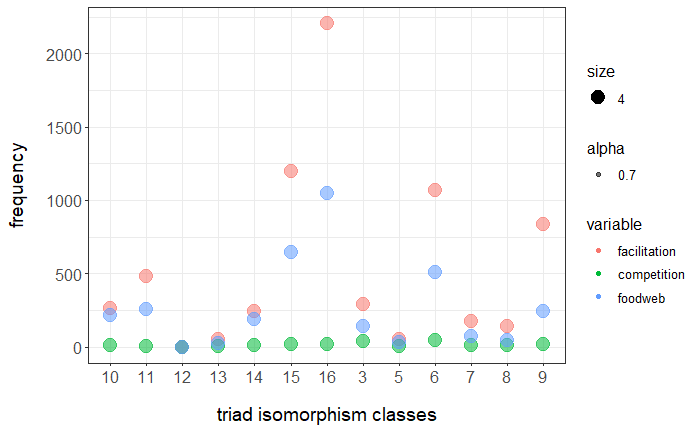

# Comparing foodweb simulated vs empirical

```r
test <- readRDS(file = "C:/Users/alexf/Desktop/PhD_Fuster-Calvo/Chapter 2 - Network_phylogeny/Network-Phylogeny/data/selection_evolution/foodweb1/fw.rds")
```

```r
get_network_measures_from_adjacency(adj_matrix_f)
```

[output not shown]

[output not shown]

[output cut: 23 more lines]